# GSBS544 Practice Activity 2.1

Author

Sahil Bains

Titanic Wrangling In this practice activity you’ll continue to work with the titanic dataset in ways that flex what you’ve learned about both data wrangling and data visualization.

```python
import pandas as pd
df = pd.read_csv('/Users/sahilbains/Downloads/CalPoly/GSB544/Assignments/Assignment2/titanic.csv')
df.info()
```

```
<class 'pandas.core.frame.DataFrame'>
RangeIndex: 2207 entries, 0 to 2206
Data columns (total 9 columns):
 #   Column    Non-Null Count  Dtype
---  ------    --------------  -----
 0   name      2207 non-null   object
 1   gender    2207 non-null   object
 2   age       2205 non-null   float64
 3   class     2207 non-null   object
 4   embarked  2207 non-null   object
 5   country   2126 non-null   object
 6   ticketno  1316 non-null   float64
 7   fare      1291 non-null   float64
 8   survived  2207 non-null   int64
dtypes: float64(3), int64(1), object(5)
memory usage: 155.3+ KB
```

1. Filter the data to include passengers only. Calculate the joint distribution (cross-tab) between a passenger’s class and where they embarked.

```python
# Subsetting for passengers in different classes
passengers = df[df['class'].isin(['1st', '2nd', '3rd'])]


# Dropping NAs from passengers
passengers = passengers.dropna(subset=['embarked'])

# Calculating joint distributions between class and embarked columns relative to each row
count = pd.crosstab(passengers['class'], passengers['embarked'], normalize='index')
print(count)
```

```
embarked         B         C         Q         S
class
1st       0.009259  0.441358  0.009259  0.540123
2nd       0.021127  0.091549  0.024648  0.862676
3rd       0.000000  0.143865  0.159379  0.696756
```

2. Using the joint distribution that calculated above, calculate the following: the conditional distribution of their class given where they embarked the conditional distribution of where they embarked given their class Use the conditional distributions that you calculate to answer the following quesitons:

What proportion of 3rd class passengers embarked at Southampton? What proportion of Southampton passengers were in 3rd class?

```python
# Conditional distribution of embark given class
cd_ec = pd.crosstab(passengers['class'], passengers['embarked'], normalize='index')

# Conditional distribution of class given embark
cd_ce = pd.crosstab(passengers['class'], passengers['embarked'], normalize='columns')

# Printing results
print('conditional distribution of embark given class: ', cd_ec)
print('conditional distribution of class given embark: ', cd_ce)

# Proportion of 3rd class passengers embarked at Southampton
prop_third_s = cd_ec.loc['3rd', 'S']
print(prop_third_s)

# Proportion of Southampton passengers that were in 3rd class
prop_s_third = cd_ce.loc['3rd', 'S']
print(prop_s_third)
```

```
conditional distribution of embark given class:  embarked         B         C         Q         S
class
1st       0.009259  0.441358  0.009259  0.540123
2nd       0.021127  0.091549  0.024648  0.862676
3rd       0.000000  0.143865  0.159379  0.696756
conditional distribution of class given embark:  embarked         B         C         Q         S
class
1st       0.333333  0.527675  0.024390  0.191466
2nd       0.666667  0.095941  0.056911  0.268053
3rd       0.000000  0.376384  0.918699  0.540481
0.6967559943582511
0.5404814004376368
```

3. Make a visualization showing the distribution of a passenger’s class, given where they embarked. Discuss the pros and cons of using this visualization versus the distributions you calculated before, to answer the previous questions.

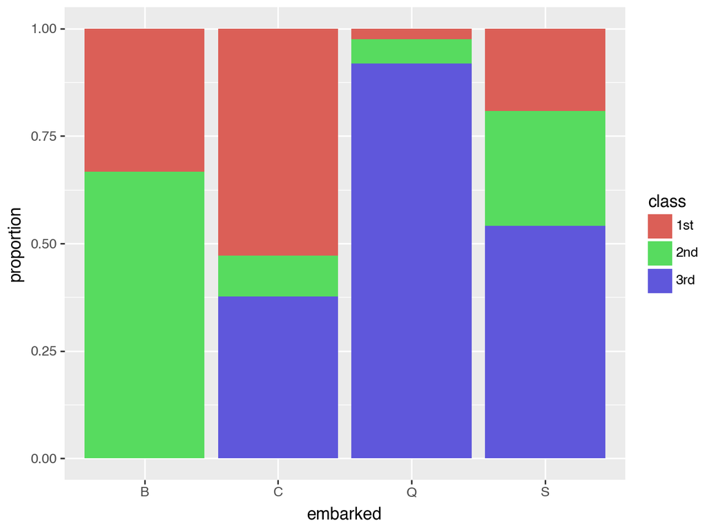

```python
from plotnine import *
# Reshaping the data to long format in order to plot
plot = cd_ce.reset_index().melt(
    id_vars='class',
    var_name='embarked',
    value_name='proportion'
)

# Plotting
(
    ggplot(plot, aes(x='embarked', y='proportion', fill='class'))
    + geom_col(position='stack')
)
```

Some of the pros of using this visualization over the distribution is that it is very intuitive to see the distribution of passenger classes over the embarked locations. By extension, you’re able to see the relative size of proportions.

Some of the cons of using this visualization over the distribution is that it is less precise, you’re not able to see the exact values. By extension, you cannot see the differences in the values as well as the raw numbers.